# index

Ana Hojan

02/06/2020

## INTRODUCTION

From 1999–2018, almost 450,000 people died from an overdose involving any opioid, including prescription and illicit opioids.[1] Opiates are drugs naturally derived from Opium and synthetically synthesized drugs, which are legally available. Opioids are prescribed primarily as pain relievers despite a high risk of addiction and overdose. The increase in deaths caused by the risks involved with the consumption of opioids was alarming and declared an epidemic.

The epidemic has been described as a “uniquely American problem”.[2] The structure of the US healthcare system, in which people not qualifying for government programs are required to obtain private insurance, favors prescribing drugs over more expensive therapies.According to Professor Judith Feinberg, “Most insurance, especially for poor people, won’t pay for anything but a pill.”[3] Prescription rates for opioids in the US are 40 percent higher than the rate in other developed countries such as Germany or Canada.[4]

## OBJECTIVES

The objective of this notebook is to perform exploratory data analysis on opioid crisis and gather insights

## DATA

This dataset contains summaries of prescription records for 250 common opioid and non-opioid drugs written by 25,000 unique licensed medical professionals in 2014 in the United States for citizens covered under Class D Medicare as well as some metadata about the doctors themselves. There are 3 dataframes: - opioids It contains a list of drug names and its generic name

```r
opioids<-read.csv("opioids.csv")
head(opioids)
```

```
## # A tibble: 6 x 2
##   Drug.Name                      Generic.Name
##   <fct>                          <fct>
## 1 ABSTRAL                        FENTANYL CITRATE
## 2 ACETAMINOPHEN-CODEINE          ACETAMINOPHEN WITH CODEINE
## 3 ACTIQ                          FENTANYL CITRATE
## 4 ASCOMP WITH CODEINE            CODEINE/BUTALBITAL/ASA/CAFFEIN
## 5 ASPIRIN-CAFFEINE-DIHYDROCODEIN DIHYDROCODEINE/ASPIRIN/CAFFEIN
## 6 AVINZA                         MORPHINE SULFATE
```

- overdoses It contains the data on the numer of deaths per state.

```r
overdoses<-as.data.frame(read.csv("overdoses.csv"))
head(overdoses)
```

```
## # A tibble: 6 x 4
##   State      Population Deaths Abbrev
##   <fct>      <fct>      <fct>  <fct>
## 1 Alabama    4,833,722  723    AL
## 2 Alaska     735,132    124    AK
## 3 Arizona    6,626,624  1,211  AZ
## 4 Arkansas   2,959,373  356    AR
## 5 California 38,332,521 4,521  CA
## 6 Colorado   5,268,367  899    CO
```

- prescriber The dataframe contains:
  - NPI - unique National Provider Identifier number
  - Gender
  - State
  - Credentials - set of initials indicative of medical degree
  - Specialty - description of type of medicinal practice
  - A long list of drugs with numeric values indicating the total number of prescriptions written for the year by that individual
  - Opioid prescriber - a boolean label indicating whether or not that individual prescribed opiate drugs more than 10 times in the year

```r
prescriber<-read.csv("prescriber-info.csv")
prescriber<-prescriber[,-c(6:255)]
head(prescriber)
```

```
## # A tibble: 6 x 6
##          NPI Gender State Credentials Specialty           Opioid.Prescriber
##        <int> <fct>  <fct> <fct>       <fct>                           <int>
## 1 1710982582 M      TX    DDS         Dentist                             1
## 2 1245278100 F      AL    MD          General Surgery                     1
## 3 1427182161 F      NY    M.D.        General Practice                    0
## 4 1669567541 M      AZ    MD          Internal Medicine                   1
## 5 1679650949 M      NV    M.D.        Hematology/Oncology                 1
## 6 1548580897 M      PA    DO          General Surgery                     1
```

## EXPLORATORY DATA ANALAYSIS

### What state has the higes and the lowest opioid death rate?

```
## # A tibble: 1 x 5
##   State        Population Deaths Abbrev DeathRate
##   <fct>        <chr>      <chr>  <fct>      <dbl>
## 1 North Dakota 723393     43     ND       0.00594
```

Lowest opioid death rate has North Dakota: 0.00594421%.

```
## # A tibble: 1 x 5
##   State         Population Deaths Abbrev DeathRate
##   <fct>         <chr>      <chr>  <fct>      <dbl>
## 1 West Virginia 1854304    627    WV        0.0338
```

Highest opioid death rate has West Wirginia: 0.03381323%.

### How many opioid prescribers are there?

```r
nrow(prescriber%>%filter(Opioid.Prescriber=="1"))
```

```
## [1] 14688
```

Out of 25000 prescriptions 14688 of those had prescribed more than 10 in 2014, thus are called regular prescriber.

### How many opioid prescribers are men and how many of them are women?

```r
nrow(prescriber%>%filter(Opioid.Prescriber=="1")%>%filter(Gender=="F"))
```

```
## [1] 5135
```

```r
nrow(prescriber%>%filter(Opioid.Prescriber=="1")%>%filter(Gender=="F"))/nrow(prescriber%>%filter(Opioid.Prescriber=="1"))*100
```

```
## [1] 34.96051
```

```r
nrow(prescriber%>%filter(Opioid.Prescriber=="1")%>%filter(Gender=="M"))
```

```
## [1] 9553
```

```r
nrow(prescriber%>%filter(Opioid.Prescriber=="1")%>%filter(Gender=="M"))/nrow(prescriber%>%filter(Opioid.Prescriber=="1"))*100
```

```
## [1] 65.03949
```

Out of 14688 opioid prescribers 9553 were men, which represents: 65,04%

### Highest number of opioid prescribers per speciality

[figure not shown]

```r
min_presc<-data.frame(prescriber%>%filter(Opioid.Prescriber=="1"))
all_presc<-prescriber
tabela<-data.frame(unique(prescriber$Specialty))
n<-c(1:109)
tabela<-cbind(tabela,n)
koncna_tabela<-data.frame()


NofPrescribtions<-function(tabela, min_presc ){
  for (variable in 1:109) {
    n<-nrow(min_presc%>%filter(Specialty==tabela[variable,1]))
    tabela[variable,2]<-n
  }
  koncna_tabela<<-tabela%>%arrange(by_group=n)
}

NofPrescribtions(tabela,min_presc)
b<-koncna_tabela%>%slice_tail(n=10)
top_30<-koncna_tabela%>%slice_tail(n=30)


ggplot(b, aes(x="",y="", fill=b$unique.prescriber.Specialty.))+
geom_bar(width = 1, stat = "identity")+ coord_polar("y", start=0) +labs(title="Pie chart of number of opioid prescribers per speciality")
```

Highest number of opioid prescribers are in the speciality of family practice whith 2653.

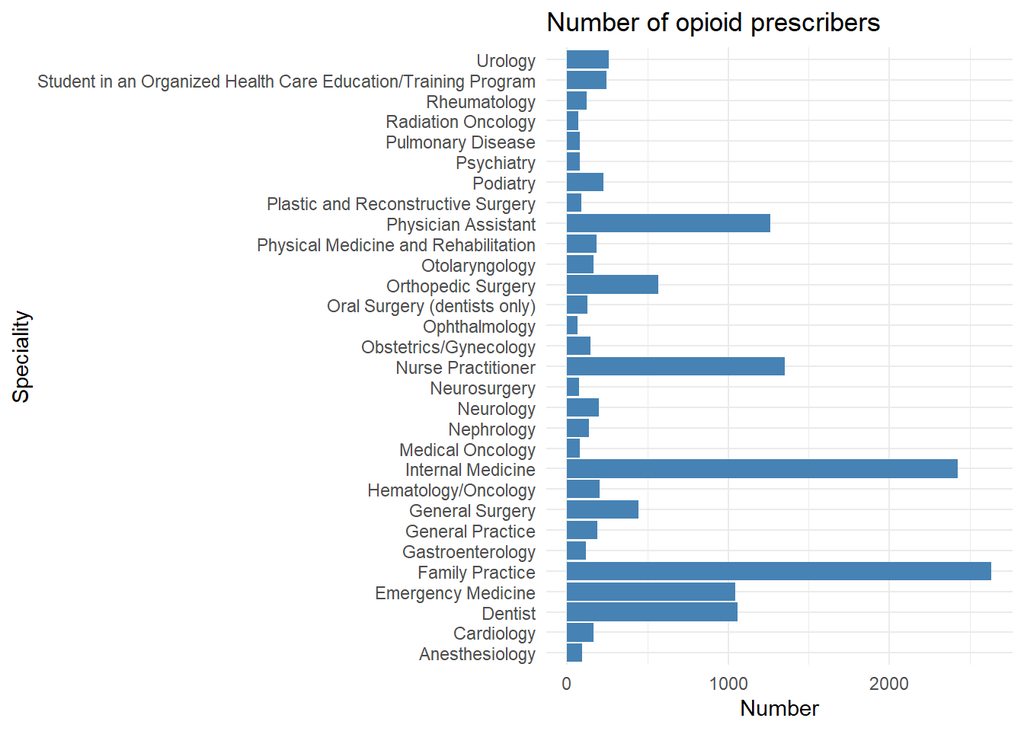

```r
s<-map_data('state')
c<-read.csv("data.csv")
c$State<-tolower(c$State)
s<-left_join(s,c,by=c("region"="State"))
data_df<-right_join(s,min_presc,by=c("Code"="State"))


n_of_opioid_prescribers_per_state<-data.frame(unique(data_df$Code))
n<-c(1:56)
f<-c(1:56)
n_of_opioid_prescribers_per_state<-cbind(n_of_opioid_prescribers_per_state,n,f)
NofPrescribtionsPerState<-function(n_of_opioid_prescribers_per_state, min_presc, all_presc){
  for (variable in 1:56) {
    n<-nrow(min_presc%>%filter(State==n_of_opioid_prescribers_per_state[variable,1]))
    n_of_opioid_prescribers_per_state[variable,2]<-n

    f<-nrow(all_presc%>%filter(State==n_of_opioid_prescribers_per_state[variable,1]))
    n_of_opioid_prescribers_per_state[variable,3]<-f
  }
   n_of_opioid_prescribers_per_state<<-n_of_opioid_prescribers_per_state%>%arrange(order_by=n)

}
NofPrescribtionsPerState(n_of_opioid_prescribers_per_state,min_presc,all_presc)

ggplot(data=top_30, aes(x=n, y=unique.prescriber.Specialty.)) +
  geom_bar(stat="identity", fill="steelblue")+
  theme_minimal()+
    labs(title = "Number of opioid prescribers",
         x = "Number",
         y = "Speciality")
```

### What regions have higher prercentage of opioid death rate?

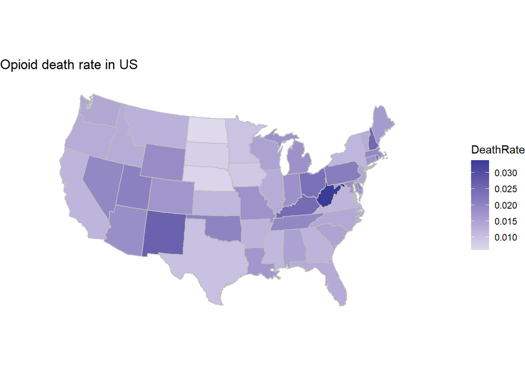

```r
overdoses$State<-tolower(overdoses$State)
overdoses<-overdoses%>%mutate(DeathRate=((as.numeric(Deaths)/(as.numeric(Population)))*100))
merge_df<-left_join(s,overdoses,by=c("region"="State"))

counties<-map_data('county')


ggplot(merge_df, aes(x=long, y=lat, group=group, fill=DeathRate)) + geom_polygon(color = 'grey') + coord_map('polyconic') + scale_fill_gradient2() +
  theme_void() + ggtitle("Opioid death rate in US")
```

### Number of opioid prescribers per state

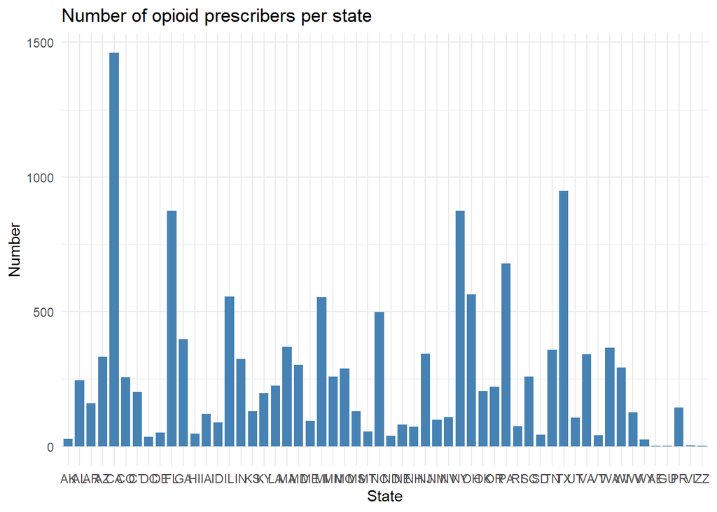

```r
ggplot(data=n_of_opioid_prescribers_per_state, aes(x=unique.data_df.Code., y=n)) +
  geom_bar(stat="identity", fill="steelblue", width = 0.8, position = position_dodge(width=0.5))+
  theme_minimal()  +
    labs(title = "Number of opioid prescribers per state",
         x = "State",
         y = "Number")
```

### Rate of opioids prescribed

```r
n_of_opioid_prescribers_per_state%>%slice_max(order_by = n)
```

```
## # A tibble: 1 x 3
##   unique.data_df.Code.     n     f
##   <fct>                <int> <int>
## 1 CA                    1462  2562
```

Highest number of opioid prescribers work in California.

```
## # A tibble: 5 x 3
##   unique.data_df.Code.     n     f
##   <fct>                <int> <int>
## 1 GU                       1     2
## 2 ZZ                       1     2
## 3 AE                       2     2
## 4 VI                       3     3
## 5 WY                      24    38
```

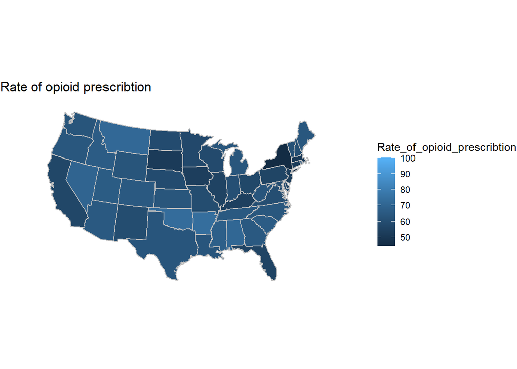

```r
n_of_opioid_prescribers_per_state<<-n_of_opioid_prescribers_per_state%>%mutate(Rate_of_opioid_prescribtion=(n/f)*100)

full_data<-left_join(n_of_opioid_prescribers_per_state,s, by=c("unique.data_df.Code."="Code"))

ggplot(full_data, aes(x=long, y=lat, group=group, fill=Rate_of_opioid_prescribtion)) + geom_polygon(color = 'grey') + coord_map('polyconic') + theme_void() +
    labs(title = "Rate of opioid prescribtion")
```

### Is there a corralation between opioid death rate and opioid prescribtion?

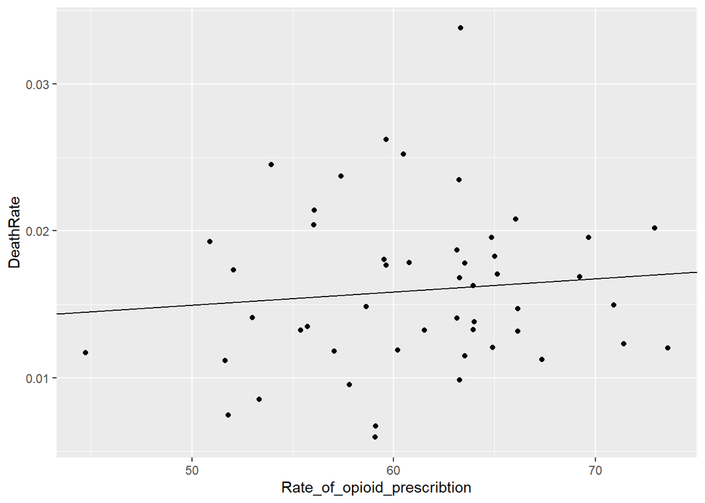

```r
merge_data<-left_join(overdoses_df, n_of_opioid_prescribers_per_state, by=c("Abbrev"="unique.data_df.Code."))
premica<-lm(DeathRate~Rate_of_opioid_prescribtion,data=merge_data)
presecisce<-premica[[1]][1]
koeficient<-premica[[1]][2]
merge_data%>%ggplot()+geom_point(aes(x=Rate_of_opioid_prescribtion,y=DeathRate))+geom_abline(slope = koeficient,intercept = presecisce)
```

```r
cor.test(merge_data$DeathRate,merge_data$Rate_of_opioid_prescribtion)
```

```
##
##  Pearson's product-moment correlation
##
## data:  merge_data$DeathRate and merge_data$Rate_of_opioid_prescribtion
## t = 0.70907, df = 48, p-value = 0.4817
## alternative hypothesis: true correlation is not equal to 0
## 95 percent confidence interval:
##  -0.1816824  0.3696851
## sample estimates:
##       cor
## 0.1018142
```

## INTERPRETATION

State wise, there are a lot more overdoses and deaths in West Virginia than the Dakota’s, and it possible but unlikely we have massively more accidents and surgeons in one state than another per capita.

Although men are more likely to be opioid prescribers, we have to take into consideration what is a gender ratio in a specialty.

## REFRENCES

[1] Wide-ranging online data for epidemiologic research (WONDER). Atlanta, GA: CDC, National Center for Health Statistics; 2020. Available at http://wonder.cdc.gov.

[2] Shipton EA, Shipton EE, Shipton AJ (June 2018). “A Review of the Opioid Epidemic: What Do We Do About It?”. Pain and Therapy. 7 (1): 23–36. doi:10.1007/s40122-018-0096-7. PMC 5993689. PMID 29623667.

[3] Amos O (October 25, 2017). “Why opioids are such an American problem”. BBC News. Retrieved December 29, 2017.

[4] Erickson A (December 28, 2017). “Analysis | Opioid abuse in the U.S. is so bad it’s lowering life expectancy. Why hasn’t the epidemic hit other countries?”. Washington Post. ISSN 0190-8286. Retrieved December 29, 2017.